# Final Project

Stat 184

Tre Butler, Phil Saroka, Jessica Schick

## Front Matter

```r
# clean up workspace environment
rm(list = ls())
# all packages used for the assignment
library(mosaicData)
library(mosaic)
library(DataComputing)
library(tidyverse)
library(forcats)
library(lubridate)
library(readxl)
```

How have outside factors like weather and time affected the crime rates of Boston?

# Data Sources:

## Where did you find them? (I don’t think we should just say Google)

- Boston crime rates data - https://www.kaggle.com/ankkur13/boston-crime-data
- Boston weather data - https://www.ncdc.noaa.gov/

## Who collected/maintains them?

- Boston crime rates data - AnkurJain formed the dataset on Kaggle, but the information to create the dataset comes from the Boston Police Department
- Boston weather data - The NOAA gathers it’s data from many sources including the World Meteorological Organization

## When & Why were they originally collected?

1. Boston crime rates data - The dataset started in 2015 and was originally collected to find trends in crime statistics.
2. Boston weather data - The NOAA has kept weather statistics for many places for the past 30 years. They are collected for convenience to those who need to study trends in the weather.

## What are some of the variables that you plan to use?

Boston crime rates data - Incident Number, Occurred on Date, Year, Month, Day of the Week, Hour, UCR Part, Street, Latitude, Longitude, Location, Offense Code Boston weather data - Name, Latitude, Longitude, Date, Precipitation, Snow, Temperature Average Plots, Summary Stats, and Observations

## TWO Data Sources (at least)

Primary data: Boston Crime Data Other data sources: Boston Weather Data

```r
#creating the datasets
boston_crime_statistics <- read_excel("crime.xlsx")
```

[output not shown]

[output not shown]

[output not shown]

[output not shown]

[output not shown]

[output not shown]

[output not shown]

[output not shown]

[output not shown]

[output not shown]

[output not shown]

[output not shown]

[output not shown]

[output not shown]

[output not shown]

[output not shown]

[output not shown]

[output not shown]

[output not shown]

[output not shown]

[output not shown]

[output not shown]

[output not shown]

[output not shown]

[output not shown]

[output not shown]

[output not shown]

[output not shown]

[output not shown]

[output not shown]

[output not shown]

[output not shown]

[output not shown]

[output not shown]

[output not shown]

[output not shown]

[output not shown]

[output not shown]

[output not shown]

[output not shown]

[output not shown]

[output not shown]

[output not shown]

[output not shown]

[output not shown]

[output not shown]

[output not shown]

[output not shown]

[output not shown]

[output not shown]

[output not shown]

[output not shown]

[output not shown]

[output not shown]

[output not shown]

[output not shown]

[output not shown]

[output not shown]

[output not shown]

[output not shown]

[output not shown]

```r
weather_data <- read_csv("weather data.csv")
weather_data <- weather_data%>%
  select(NAME,LATITUDE,LONGITUDE,DATE,PRCP, TAVG,SNOW)
```

```r
boston_crime_statistics
```

| INCIDENT_NUMBER | OFFENSE_CODE | OFFENSE_CODE_GROUP | OFFENSE_DESCRIPTION | DISTRICT | REPORTING_AREA | SHOOTING | OCCURRED_ON_DATE | YEAR | MONTH | DAY_OF_WEEK | HOUR | UCR_PART | STREET | Lat | Long | Location |
| --- | --- | --- | --- | --- | --- | --- | --- | --- | --- | --- | --- | --- | --- | --- | --- | --- |
| I182080058 | 2403 | Disorderly Conduct | DISTURBING THE PEACE | E18 | 495 | NA | 2018-10-03 20:13:00 | 2018 | 10 | Wednesday | 20 | Part Two | ARLINGTON ST | 42.26261 | -71.12119 | (42.26260773, -71.12118637) |
| I182080053 | 3201 | Property Lost | PROPERTY - LOST | D14 | 795 | NA | 2018-08-30 20:00:00 | 2018 | 8 | Thursday | 20 | Part Three | ALLSTON ST | 42.35211 | -71.13531 | (42.35211146, -71.13531147) |
| I182080052 | 2647 | Other | THREATS TO DO BODILY HARM | B2 | 329 | NA | 2018-10-03 19:20:00 | 2018 | 10 | Wednesday | 19 | Part Two | DEVON ST | 42.30813 | -71.07693 | (42.30812619, -71.07692974) |
| I182080051 | 413 | Aggravated Assault | ASSAULT - AGGRAVATED - BATTERY | A1 | 92 | NA | 2018-10-03 20:00:00 | 2018 | 10 | Wednesday | 20 | Part One | CAMBRIDGE ST | 42.35945 | -71.05965 | (42.35945371, -71.05964817) |
| I182080050 | 3122 | Aircraft | AIRCRAFT INCIDENTS | A7 | 36 | NA | 2018-10-03 20:49:00 | 2018 | 10 | Wednesday | 20 | Part Three | PRESCOTT ST | 42.37526 | -71.02466 | (42.37525782, -71.02466343) |
| I182080049 | 1402 | Vandalism | VANDALISM | C11 | 351 | NA | 2018-10-02 20:40:00 | 2018 | 10 | Tuesday | 20 | Part Two | DORCHESTER AVE | 42.29920 | -71.06047 | (42.29919694, -71.06046974) |
| I182080048 | 3803 | Motor Vehicle Accident Response | M/V ACCIDENT - PERSONAL INJURY | NA | NA | NA | 2018-10-03 20:16:00 | 2018 | 10 | Wednesday | 20 | Part Three | NA | 42.32073 | -71.05676 | (42.32073413, -71.05676415) |
| I182080047 | 3301 | Verbal Disputes | VERBAL DISPUTE | B2 | 603 | NA | 2018-10-03 19:32:00 | 2018 | 10 | Wednesday | 19 | Part Three | TREMONT ST | 42.33381 | -71.10378 | (42.33380683, -71.10377843) |
| I182080045 | 802 | Simple Assault | ASSAULT SIMPLE - BATTERY | E18 | 543 | NA | 2018-10-03 19:27:00 | 2018 | 10 | Wednesday | 19 | Part Two | AVILA RD | 42.25614 | -71.12803 | (42.25614494, -71.12802506) |
| I182080044 | 3410 | Towed | TOWED MOTOR VEHICLE | D4 | 621 | NA | 2018-10-03 20:00:00 | 2018 | 10 | Wednesday | 20 | Part Three | COMMONWEALTH AVE | 42.34887 | -71.08936 | (42.34886600, -71.08936284) |

[output cut: 990 more lines]

```r
weather_data
```

| NAME | LATITUDE | LONGITUDE | DATE | PRCP | TAVG | SNOW |
| --- | --- | --- | --- | --- | --- | --- |
| BOSTON, MA US | 42.3606 | -71.0097 | 2015-06-01 | 0.38 | 48 | 0.0 |
| BOSTON, MA US | 42.3606 | -71.0097 | 2015-06-02 | 0.74 | 47 | 0.0 |
| BOSTON, MA US | 42.3606 | -71.0097 | 2015-06-03 | 0.00 | 50 | 0.0 |
| BOSTON, MA US | 42.3606 | -71.0097 | 2015-06-04 | 0.00 | 52 | 0.0 |
| BOSTON, MA US | 42.3606 | -71.0097 | 2015-06-05 | 0.00 | 54 | 0.0 |
| BOSTON, MA US | 42.3606 | -71.0097 | 2015-06-06 | 0.09 | 58 | 0.0 |
| BOSTON, MA US | 42.3606 | -71.0097 | 2015-06-07 | 0.00 | 59 | 0.0 |
| BOSTON, MA US | 42.3606 | -71.0097 | 2015-06-08 | 0.00 | 63 | 0.0 |
| BOSTON, MA US | 42.3606 | -71.0097 | 2015-06-09 | 0.00 | 69 | 0.0 |
| BOSTON, MA US | 42.3606 | -71.0097 | 2015-06-10 | 0.00 | 71 | 0.0 |

[output cut: 990 more lines]

```r
date_of_incident <- boston_crime_statistics%>%
  select(INCIDENT_NUMBER,OCCURRED_ON_DATE,YEAR,MONTH,DAY_OF_WEEK,HOUR)%>%
  arrange(OCCURRED_ON_DATE)
loaction_of_incident <- boston_crime_statistics%>%
  select(INCIDENT_NUMBER,OCCURRED_ON_DATE,UCR_PART,STREET,Lat,Long, Location)%>%
  arrange(OCCURRED_ON_DATE)
```

```r
date_of_incident
```

| INCIDENT_NUMBER | OCCURRED_ON_DATE | YEAR | MONTH | DAY_OF_WEEK | HOUR |
| --- | --- | --- | --- | --- | --- |
| I182061268 | 2015-06-15 00:00:00 | 2015 | 6 | Monday | 0 |
| I172040657 | 2015-06-15 00:00:00 | 2015 | 6 | Monday | 0 |
| I162013546 | 2015-06-15 00:00:00 | 2015 | 6 | Monday | 0 |
| I152067251 | 2015-06-15 00:00:00 | 2015 | 6 | Monday | 0 |
| I152059178 | 2015-06-15 00:00:00 | 2015 | 6 | Monday | 0 |
| I152054279 | 2015-06-15 00:00:00 | 2015 | 6 | Monday | 0 |
| I152051083 | 2015-06-15 00:00:00 | 2015 | 6 | Monday | 0 |
| I152051083 | 2015-06-15 00:00:00 | 2015 | 6 | Monday | 0 |
| I152049897 | 2015-06-15 00:00:00 | 2015 | 6 | Monday | 0 |
| I152049594 | 2015-06-15 00:01:00 | 2015 | 6 | Monday | 0 |

[output cut: 990 more lines]

```r
loaction_of_incident
```

| INCIDENT_NUMBER | OCCURRED_ON_DATE | UCR_PART | STREET | Lat | Long | Location |
| --- | --- | --- | --- | --- | --- | --- |
| I182061268 | 2015-06-15 00:00:00 | Part Three | BERNARD | -1.00000 | -1.00000 | (-1.00000000, -1.00000000) |
| I172040657 | 2015-06-15 00:00:00 | Part Two | MELBOURNE ST | 42.29109 | -71.06595 | (42.29109287, -71.06594539) |
| I162013546 | 2015-06-15 00:00:00 | Part Three | NORFOLK ST | 42.28363 | -71.08281 | (42.28363434, -71.08281320) |
| I152067251 | 2015-06-15 00:00:00 | Part Two | FANEUIL HALL SQ | 42.36020 | -71.05621 | (42.36020464, -71.05620816) |
| I152059178 | 2015-06-15 00:00:00 | Part Two | WASHINGTON ST | 42.29361 | -71.07189 | (42.29360585, -71.07188650) |
| I152054279 | 2015-06-15 00:00:00 | Part Two | HARLEM ST | 42.30022 | -71.08098 | (42.30021684, -71.08097940) |
| I152051083 | 2015-06-15 00:00:00 | Part Three | PARIS ST | 42.37702 | -71.03225 | (42.37702319, -71.03224730) |
| I152051083 | 2015-06-15 00:00:00 | Part Three | PARIS ST | 42.37702 | -71.03225 | (42.37702319, -71.03224730) |
| I152049897 | 2015-06-15 00:00:00 | Part Three | WASHINGTON ST | 42.32866 | -71.08563 | (42.32866284, -71.08563401) |
| I152049594 | 2015-06-15 00:01:00 | Part Two | HANCOCK ST | 42.31043 | -71.06134 | (42.31043400, -71.06134010) |

[output cut: 990 more lines]

```r
#date ranges
first_date<-boston_crime_statistics%>%
  select(OCCURRED_ON_DATE,YEAR,MONTH,DAY_OF_WEEK,HOUR)%>%
  arrange(OCCURRED_ON_DATE)%>%
  head(1)
last_date<-boston_crime_statistics%>%
  select(OCCURRED_ON_DATE,YEAR,MONTH,DAY_OF_WEEK,HOUR)%>%
  arrange(OCCURRED_ON_DATE)%>%
  tail(1)
first_date
```

| OCCURRED_ON_DATE | YEAR | MONTH | DAY_OF_WEEK | HOUR |
| --- | --- | --- | --- | --- |
| 2015-06-15 | 2015 | 6 | Monday | 0 |

```r
last_date
```

| OCCURRED_ON_DATE | YEAR | MONTH | DAY_OF_WEEK | HOUR |
| --- | --- | --- | --- | --- |
| 2018-10-03 20:49:00 | 2018 | 10 | Wednesday | 20 |

```r
#number of day over which the data is recorded
last_date[1, "OCCURRED_ON_DATE"]-first_date[1, "OCCURRED_ON_DATE"]
```

| OCCURRED_ON_DATE |
| --- |
| 1206.867 days |

```r
small_data <- boston_crime_statistics%>%
  group_by(OFFENSE_CODE)%>%
  summarise(total = n())
```

## Create some informative plots and summary statistics

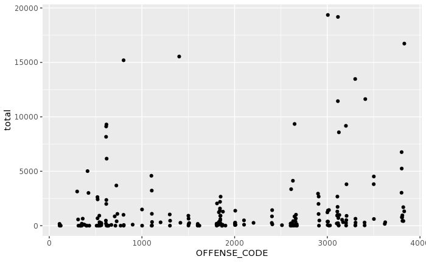

```r
ggplot(data=small_data,aes(x=OFFENSE_CODE,y=total))+geom_point()
```

In this graph we can see that there are clusters of offense codes that are more common that others